# Utilizing Technology to Support Collaborative Problem-Solving of K-12 Students in STEM Education: A multivariate multi-level meta-Analysis

© Reza Norouzian

Completed as a member of Marzieh Dehghan-Chaleshtori’s doctoral dissertation committee, (2025)

# 1 Data and analyses

To better understand the variables involved in the analyses (e.g., those used for estimating Hedges’ *g* effect sizes), the next Table provides a list of their names and definitions. (*Click on `Code` on the bottom right for the reproducible codes used in each section*).

```r
# We use the software package introduced by Norouzian & Bui (2024)
source("https://raw.githubusercontent.com/rnorouzian/i/master/3m.r")


library(knitr)
library(flextable)
library(kableExtra)
library(rmarkdown)

opts_chunk$set(message=FALSE, warning=FALSE, fig.align="center")

dat7 <- read.csv("https://raw.githubusercontent.com/fpqq/w/refs/heads/main/stem.csv")

results <- readRDS(url("https://github.com/fpqq/w/raw/refs/heads/main/stm.rds"))

moderators_abb_names <- names(results)

table_names <- c(
"Time",
"Treatment Type",
"Outcome Orientation",
"Feedback Availability",
"Subject",
"Grade Band",
"Tech Level",
"Continent",
"Group Size",
"Age")


# A list of time and moderators interacting with time
LIST <- c("time", map(moderators_abb_names[-1], c, "time"))

effect_no <- setNames(map(LIST, ~effect_count(dat7, study, !!!syms(.),
                                              show0=FALSE, na.rm=TRUE,
                                              arrange_by="time",
                                              subset = time!="posttest2")), table_names)


results <- setNames(results, table_names)
```

# 2 Definition of the additional variables beyond moderators

The additional variables beyond moderators

| Variable | Definition |
| --- | --- |
| study | Author(s) |
| year | Year of publication |
| gray | Gray literature binary identifier (i.e., research produced by less visible or well-known publishers or by organizations outside of the traditional commercial or academic publishing and distribution ch… |
| assign_type | Assignment of groups by class or by student |
| n_class | Total number of classes assigned to all groups |
| Nt | Total number of students in all classes assigned to treatments |
| Nc | Total number of students in all classes assigned to control |
| sample_id | Numerical index of the independent samples of participants |
| g | Effect size estimates before assign_type adjustment |
| v_g | Sampling variances before assign_type adjustment |
| g2 | Effect size estimates after assign_type adjustment |
| v_g2 | Sampling variances after assign_type adjustment |
| nT | Number of participants in each treatment group |
| mT | Mean of each treatment group |
| sdT | Standard deviation of each treatment group |
| nC | Number of participants in the control group |
| mC | Mean of the control group |
| sdC | Standard deviation of the control group |
| effect | Numerical index of each row |
| SE_egger | Modified standard error of Hedges' g for Egger's test purposes based on Pustejovsky and Rogers (2019) |

# 3 Display of data and preliminary descriptive analyses

Once again, *click on `Code` on the bottom right for the reproducible codes used in each section*.

# 4 Distribution Summary of Effect Sizes

```r
g <- dat7 %>%
  group_by(study) %>%
  summarise(n_gi = n()) %>%
  summarise(
    `No. of Studies` = n(),
    `No. of Effects` = sum(n_gi),
    `Min. Effects in Study` = min(n_gi),
    `Max. Effects in Study` = max(n_gi),
    `Median Effects in Study` = median(n_gi)
  ) %>% ungroup()


flextable(g) %>%
  autofit() %>% set_caption("Distribution Summary of Effect Sizes") %>% fontsize(size = 11, part = "all") %>%
  line_spacing(space = .6, part = "all")
```

Distribution Summary of Effect Sizes

| No. of Studies | No. of Effects | Min. Effects in Study | Max. Effects in Study | Median Effects in Study |
| --- | --- | --- | --- | --- |
| 23 | 157 | 2 | 26 | 4 |

# 5 Publication Bias

## 5.1 Funnel plot at study level

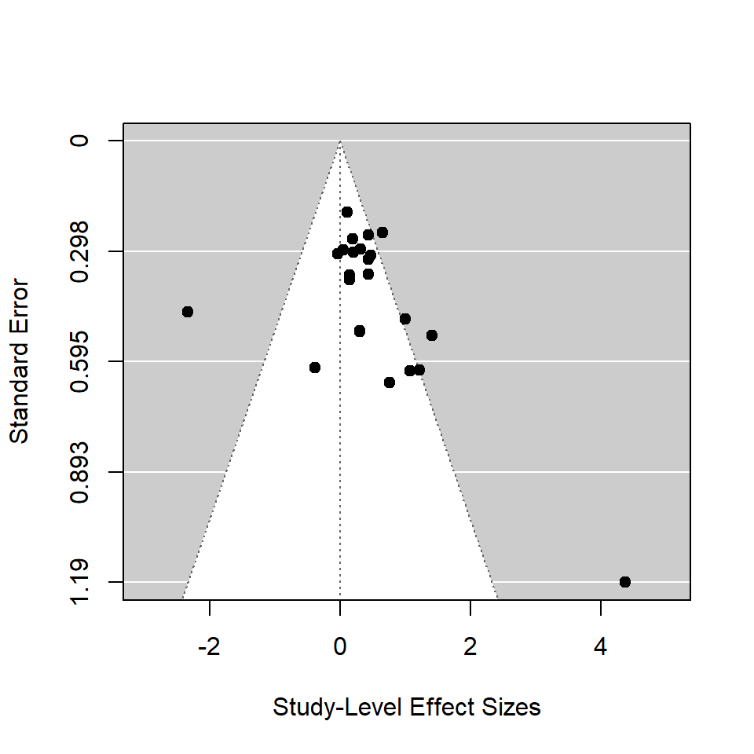

Figure 3. Contour-Enhanced Funnel Plot of Study-Level Effects

```r
###############################
# 3M publication bias detection
###############################

# Naturally existing dependence from previous section
Vs = with(dat7, impute_covariance_matrix(v_g2, study, r=.5,
                                        subgroup = sample_id))

# Magnitude of within-study correlations
rho <- 0.5

# Aggregate effects at Study level (level 3)
data_agg_study <-
  dat7 %>%
  escalc(data = ., yi = g2, vi = v_g2) %>%
  aggregate.escalc(cluster = study, rho = rho, weighted = FALSE)

# Contour plot at study level
with(data_agg_study,
     contour_funnel(x = g2,
                    vi = v_g2, sig = FALSE,
                    xlab = "Study-Level Effect Sizes"))


box()
```

```r
# This time get the tabular counts of study-level effects that are sig.
# g <- with(data_agg_study,
#      contour_funnel(x = g2,
#                     vi = v_g2, sig = TRUE))

flextable(g) %>%
  autofit() %>% set_caption("Statistically significant study level effects") %>% fontsize(size = 11, part = "all") %>%
  line_spacing(space = .6, part = "all")
```

Statistically significant study level effects

| Total | Total(%) | Left | Left(%) | Right | Right(%) | Sig. |
| --- | --- | --- | --- | --- | --- | --- |
| 6 | 26.09 | 1 | 4.35 | 5 | 21.74 | 0.05 |

## 5.2 Funnel plot at effect size level

Figure 4 displays the studies’ individual effect size estimates. As before, the dotted triangle indicates the boundaries for statistical significance on either side of the *null effect* (i.e., *no individual effect in reality exists; 0*). As can be seen, there are 29 effect size estimates that are statistically significant in magnitude and positive in direction. This value constitutes ~18% percent of the total number of effect sizes in our meta-analysis. On the other hand, there are 8 effect size estimates that are statistically significant in magnitude and *negative* in direction. This value constitutes ~5% percent of the total number of effect sizes in our meta-analysis.

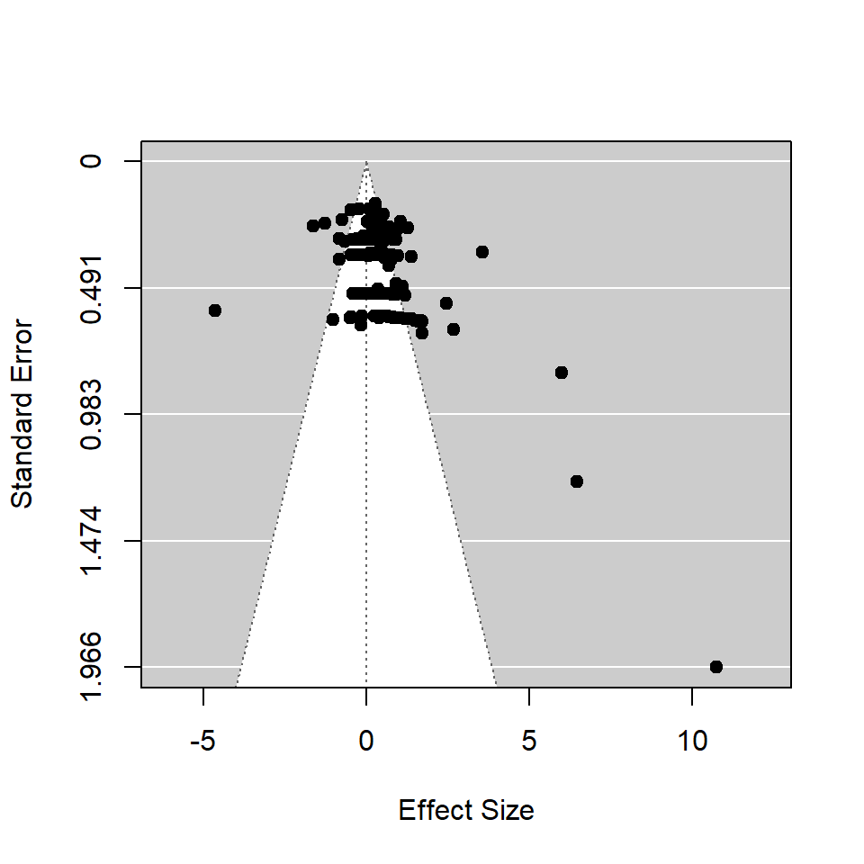

Figure 4. Contour-Enhanced Funnel Plot of Individual Effects

```r
# Contour plot at effect size level
with(dat7,
      contour_funnel(x = g2,
                     vi = v_g2, sig = FALSE))

box()
```

```r
# This time get the tabular counts of individual effects that are sig.
# g <- with(dat7,
#      contour_funnel(x = g2,
#                     vi = v_g2, sig = TRUE))

flextable(g) %>%
  autofit() %>% set_caption("Statistically significant individual effects") %>% fontsize(size = 11, part = "all") %>%
  line_spacing(space = .6, part = "all")
```

Statistically significant individual effects

| Total | Total(%) | Left | Left(%) | Right | Right(%) | Sig. |
| --- | --- | --- | --- | --- | --- | --- |
| 37 | 23.57 | 8 | 5.1 | 29 | 18.47 | 0.05 |

## 5.3 Egger’s test

We also conducted an Egger’s test ([Egger, Smith, Schneider, & Minder, 1997](https://doi.org/10.1136/bmj.315.7109.629)) of funnel plot symmetry. Using this test, we examined the extent to which the standard error (as a measure of precision) of the effect sizes collected from the Technology to Support Collaborative Problem-Solving literature related to the effect sizes’ magnitude. If such a relationship and/or its estimate of intercept, with the latter sometimes referred to as a *precision-effect test (PET)*, rise to statistically significant levels, that could suggest asymmetry (and potentially publication bias) in the funnel plot of effect sizes.

In our case, given that the p-value for the Egger’s test for the relationship in question (*b* = 1.859, *p* = 0.107; 95% CI[-0.409, 4.127]) and its estimate of intercept (*a* = -0.210, *p* = 0.485; 95% CI[-0.822, 0.403]) are both larger than 0.05, we concluded that our funnel plot is sufficiently symmetric and the likelihood of publication bias in the collected sample of Technology to Support Collaborative Problem-Solving studies is small with the caveat that the *b* estimate has a relatively wide CI.

```r
# Eggers test using the same naturally and statistically occurring dependence
ff = rma.mv(g2 ~ SE_egger, V = Vs,
            random = ~1|study/effect, data = dat7,
            dfs = "contain")

g <- results_rma(ff, drop_rows = 3:7, drop_cols = 9:10, tidy = TRUE)

flextable(dplyr::select(g, -Df)) %>%
  autofit() %>% set_caption("Egger's Test Results") %>% fontsize(size = 11, part = "all") %>%
  line_spacing(space = .6, part = "all")
```

Egger's Test Results

| Terms | Estimate | SE | t | p-value | Sig. | Lower | Upper |
| --- | --- | --- | --- | --- | --- | --- | --- |
| (Intercept) | -0.210 | 0.295 | -0.711 | 0.485 |  | -0.822 | 0.403 |
| SE_egger | 1.859 | 1.148 | 1.619 | 0.107 |  | -0.409 | 4.127 |

# 6 Results of analyses

In this section, we present the results of our analyses in two parts. In the first part, we present the synthesized effects at each time point. As mentioned in the manuscript, results based on a limited number of effects (**M**) and/or studies (**K**) should be ignored due to their unreliable nature.

Also presented in the first part is the $R^2$ test of heterogeneity. $R^2$ indicates the percentage of change in the total heterogeneity (between- and within the studies) in the true effects of Technology to Support Collaborative Problem-Solving from a model without any MUTOS moderator (a null model) to that from a model that includes a set of MUTOS moderators of interest.

While necessary, the results presented in the first part may not by themselves immediately translate into evidence-based recommendations. This is because the descriptive (synthesized average effects) and the associated inferential results (CIs and p-values) simply denote how much effect at each measurement occasion exists and if that effect is reliably different from 0 at that point in time.

In the second part, we compare the changes that occurred in learners’ performance from one measurement occasion (baseline) to another (post-test) to specifically measure the potential learning *“gains”* that might have resulted from Technology to Support Collaborative Problem-Solving treatments taking into account the methodological differences that differentiate the studies to varying degrees (see Table 2 in the manuscript for more details on moderators).

Because the second part allows us to measure the gains from Technology to Support Collaborative Problem-Solving across more than one occasion, the results (i.e., synthesized average effects and their associated CIs and p-values) more immediately translate into evidence-based recommendations. To further facilitate such recommendations, in the second part we also measure a minimum expected benefit of using technology presented in the universal metric of percentages.

## 6.1 Effects at each time

```r
rs <- results

invisible(lapply(table_names, \(i){


  cat(paste0("\n\n### ", i, "\n"))


g <- rs[[i]]$ems


g3 <- rs[[i]]$plot

g4 <- rs[[i]]$R2

print(g3)


if(i!="Age")  { print(kable(dplyr::select(cbind(g$table, dplyr::select(effect_no[[i]], `n study`, `n effect`)), -Df) %>% rename(K=`n study`, M=`n effect`),format = "simple", table.attr = "style='width:40%;'",
            caption = paste("3M results for",tolower(i),"categories")) %>%
  kable_styling(bootstrap_options = "bordered",
                full_width = TRUE, font_size = 9.5)) } else {


print(kable(dplyr::select(g$table, -Df),format = "simple", table.attr = "style='width:40%;'",
            caption = paste("3M results for",tolower(i),"categories/trends")) %>%
  kable_styling(bootstrap_options = "bordered",
                full_width = TRUE, font_size = 9.5))

}


print(kable(g4 %>% rename(`Total Heterogeneity`=`Sigma(total)`, `Between-study Heterogeneity`=`Sigma(study)`, `Within-study Heterogeneity`=`Sigma(effect)`), format = "simple", table.attr = "style='width:40%;'",
            caption = paste("R2 test of heterogeneity for",tolower(i)) ) %>%
    add_footnote(c("Heterogeneity is in SD unit.",paste("The *p-value* indicates the statistical significance of the MUTOS moderators in the",i, "model *collectively*."))) %>%
  kable_styling(bootstrap_options = "bordered",
                full_width = TRUE, font_size = 9.5))

}))
```

### 6.1.1 Time

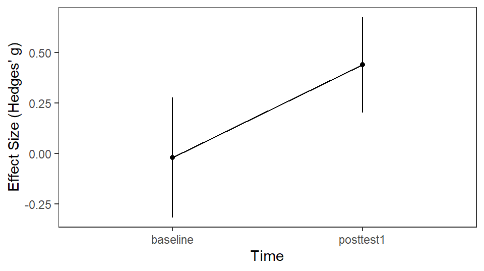

3M results for time categories

| time | Mean | SE | Lower | Upper | t | p-value | Sig. | K | M |
| --- | --- | --- | --- | --- | --- | --- | --- | --- | --- |
| baseline | -0.019 | 0.140 | -0.316 | 0.278 | -0.135 | 0.894 |  | 13 | 45 |
| posttest1 | 0.439 | 0.111 | 0.203 | 0.675 | 3.939 | 0.001 | ** | 23 | 106 |

R2 test of heterogeneity for time

| Model | Total Heterogeneity | Between-study Heterogeneity | Within-study Heterogeneity | p-value | R2 |
| --- | --- | --- | --- | --- | --- |
| No (M)UTOS | 0.686 | 0.000 | 0.686 |  |  |
| Time | 0.651 | 0.000 | 0.651 | 0.182 | 5.138% |

**Note:** <sup>a</sup> Heterogeneity is in SD unit. <sup>b</sup> The *p-value* indicates the statistical significance of the MUTOS moderators in the Time model *collectively*.

### 6.1.2 Treatment Type

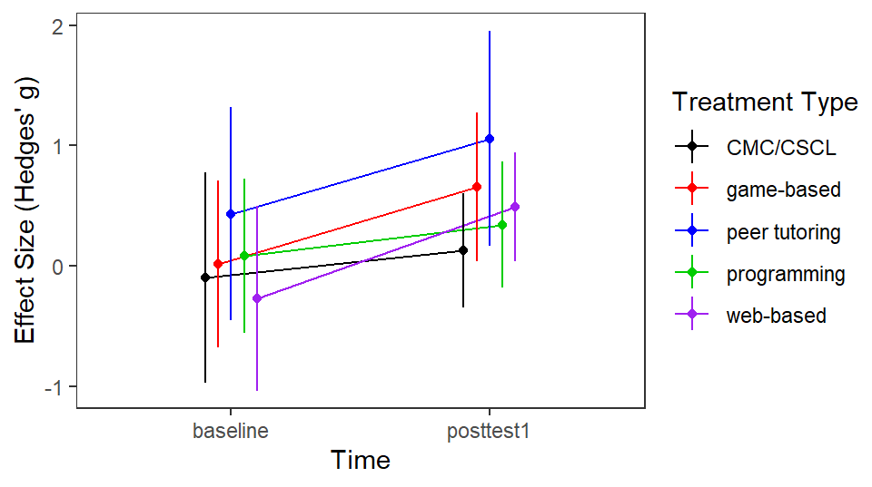

3M results for treatment type categories

| treat_grp | time | Mean | SE | Lower | Upper | t | p-value | Sig. | K | M |
| --- | --- | --- | --- | --- | --- | --- | --- | --- | --- | --- |
| CMC/CSCL | baseline | -0.096 | 0.379 | -0.970 | 0.779 | -0.253 | 0.807 |  | 2 | 5 |
| game-based | baseline | 0.016 | 0.300 | -0.676 | 0.707 | 0.052 | 0.959 |  | 5 | 10 |
| peer tutoring | baseline | 0.432 | 0.384 | -0.454 | 1.318 | 1.124 | 0.294 |  | 3 | 8 |
| programming | baseline | 0.086 | 0.277 | -0.553 | 0.724 | 0.309 | 0.765 |  | 2 | 14 |
| web-based | baseline | -0.270 | 0.332 | -1.035 | 0.495 | -0.814 | 0.439 |  | 1 | 8 |
| CMC/CSCL | posttest1 | 0.130 | 0.206 | -0.346 | 0.605 | 0.628 | 0.548 |  | 5 | 22 |
| game-based | posttest1 | 0.655 | 0.268 | 0.037 | 1.273 | 2.445 | 0.040 | * | 5 | 17 |
| peer tutoring | posttest1 | 1.059 | 0.387 | 0.166 | 1.952 | 2.734 | 0.026 | * | 3 | 8 |
| programming | posttest1 | 0.341 | 0.227 | -0.182 | 0.865 | 1.502 | 0.171 |  | 4 | 22 |
| web-based | posttest1 | 0.492 | 0.196 | 0.041 | 0.942 | 2.514 | 0.036 | * | 6 | 37 |

R2 test of heterogeneity for treatment type

| Model | Total Heterogeneity | Between-study Heterogeneity | Within-study Heterogeneity | p-value | R2 |
| --- | --- | --- | --- | --- | --- |
| No (M)UTOS | 0.686 | 0.000 | 0.686 |  |  |
| Treatment Type | 0.668 | 0.000 | 0.668 | 0.260 | 2.671% |

**Note:** <sup>a</sup> Heterogeneity is in SD unit. <sup>b</sup> The *p-value* indicates the statistical significance of the MUTOS moderators in the Treatment Type model *collectively*.

### 6.1.3 Outcome Orientation

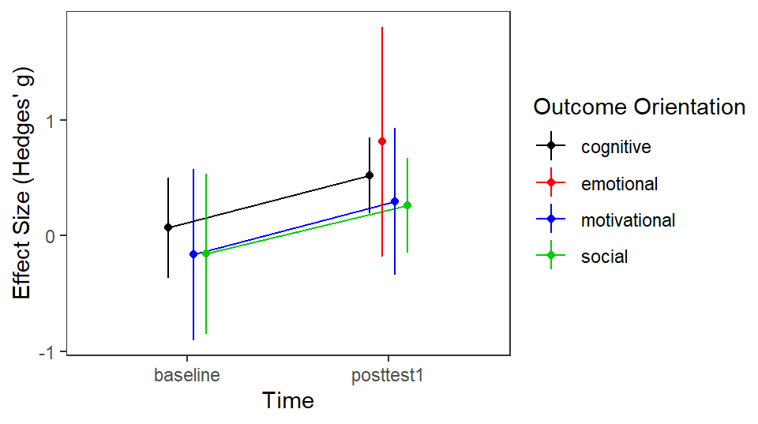

3M results for outcome orientation categories

|  | outcome.orientation | time | Mean | SE | Lower | Upper | t | p-value | Sig. | K | M |
| --- | --- | --- | --- | --- | --- | --- | --- | --- | --- | --- | --- |
| 1 | cognitive | baseline | 0.068 | 0.194 | -0.364 | 0.499 | 0.350 | 0.734 |  | 10 | 29 |
| 3 | motivational | baseline | -0.163 | 0.331 | -0.902 | 0.575 | -0.493 | 0.632 |  | 6 | 10 |
| 4 | social | baseline | -0.158 | 0.310 | -0.849 | 0.533 | -0.508 | 0.622 |  | 2 | 6 |
| 5 | cognitive | posttest1 | 0.518 | 0.146 | 0.192 | 0.844 | 3.544 | 0.005 | ** | 21 | 66 |
| 6 | emotional | posttest1 | 0.810 | 0.445 | -0.182 | 1.801 | 1.819 | 0.099 | . | 3 | 3 |
| 7 | motivational | posttest1 | 0.294 | 0.284 | -0.340 | 0.927 | 1.032 | 0.326 |  | 9 | 15 |
| 8 | social | posttest1 | 0.263 | 0.184 | -0.147 | 0.672 | 1.428 | 0.184 |  | 8 | 22 |

R2 test of heterogeneity for outcome orientation

| Model | Total Heterogeneity | Between-study Heterogeneity | Within-study Heterogeneity | p-value | R2 |
| --- | --- | --- | --- | --- | --- |
| No (M)UTOS | 0.686 | 0.000 | 0.686 |  |  |
| Outcome Orientation | 0.663 | 0.000 | 0.663 | 0.115 | 3.283% |

**Note:** <sup>a</sup> Heterogeneity is in SD unit. <sup>b</sup> The *p-value* indicates the statistical significance of the MUTOS moderators in the Outcome Orientation model *collectively*.

### 6.1.4 Feedback Availability

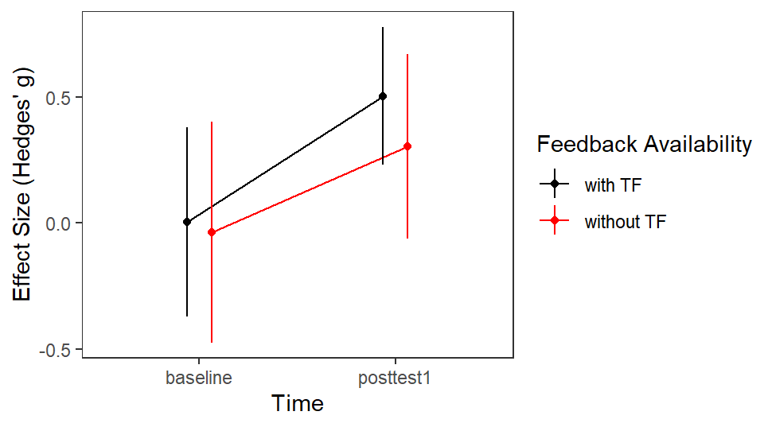

3M results for feedback availability categories

| feedback_type | time | Mean | SE | Lower | Upper | t | p-value | Sig. | K | M |
| --- | --- | --- | --- | --- | --- | --- | --- | --- | --- | --- |
| with TF | baseline | 0.003 | 0.175 | -0.372 | 0.379 | 0.020 | 0.985 |  | 7 | 29 |
| without TF | baseline | -0.037 | 0.204 | -0.474 | 0.400 | -0.182 | 0.858 |  | 7 | 16 |
| with TF | posttest1 | 0.503 | 0.127 | 0.230 | 0.777 | 3.950 | 0.001 | ** | 14 | 79 |
| without TF | posttest1 | 0.303 | 0.171 | -0.062 | 0.669 | 1.779 | 0.097 | . | 10 | 27 |

R2 test of heterogeneity for feedback availability

| Model | Total Heterogeneity | Between-study Heterogeneity | Within-study Heterogeneity | p-value | R2 |
| --- | --- | --- | --- | --- | --- |
| No (M)UTOS | 0.686 | 0.000 | 0.686 |  |  |
| Feedback Availability | 0.652 | 0.000 | 0.652 | 0.412 | 4.997% |

**Note:** <sup>a</sup> Heterogeneity is in SD unit. <sup>b</sup> The *p-value* indicates the statistical significance of the MUTOS moderators in the Feedback Availability model *collectively*.

### 6.1.5 Subject

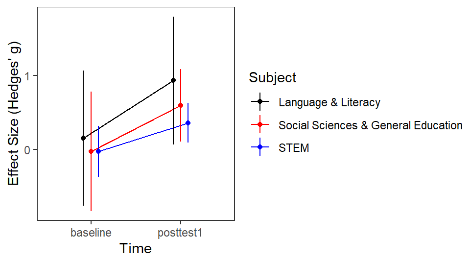

3M results for subject categories

| subject | time | Mean | SE | Lower | Upper | t | p-value | Sig. | K | M |
| --- | --- | --- | --- | --- | --- | --- | --- | --- | --- | --- |
| Language & Literacy | baseline | 0.152 | 0.420 | -0.763 | 1.067 | 0.362 | 0.724 |  | 3 | 5 |
| Social Sciences & General Education | baseline | -0.025 | 0.370 | -0.832 | 0.782 | -0.068 | 0.947 |  | 3 | 6 |
| STEM | baseline | -0.029 | 0.157 | -0.371 | 0.313 | -0.184 | 0.857 |  | 7 | 34 |
| Language & Literacy | posttest1 | 0.929 | 0.396 | 0.066 | 1.793 | 2.345 | 0.037 | * | 3 | 6 |
| Social Sciences & General Education | posttest1 | 0.596 | 0.224 | 0.108 | 1.085 | 2.659 | 0.021 | * | 5 | 24 |
| STEM | posttest1 | 0.360 | 0.124 | 0.089 | 0.630 | 2.893 | 0.013 | * | 15 | 76 |

R2 test of heterogeneity for subject

| Model | Total Heterogeneity | Between-study Heterogeneity | Within-study Heterogeneity | p-value | R2 |
| --- | --- | --- | --- | --- | --- |
| No (M)UTOS | 0.686 | 0.000 | 0.686 |  |  |
| Subject | 0.658 | 0.039 | 0.657 | 0.166 | 4.041% |

**Note:** <sup>a</sup> Heterogeneity is in SD unit. <sup>b</sup> The *p-value* indicates the statistical significance of the MUTOS moderators in the Subject model *collectively*.

### 6.1.6 Grade Band

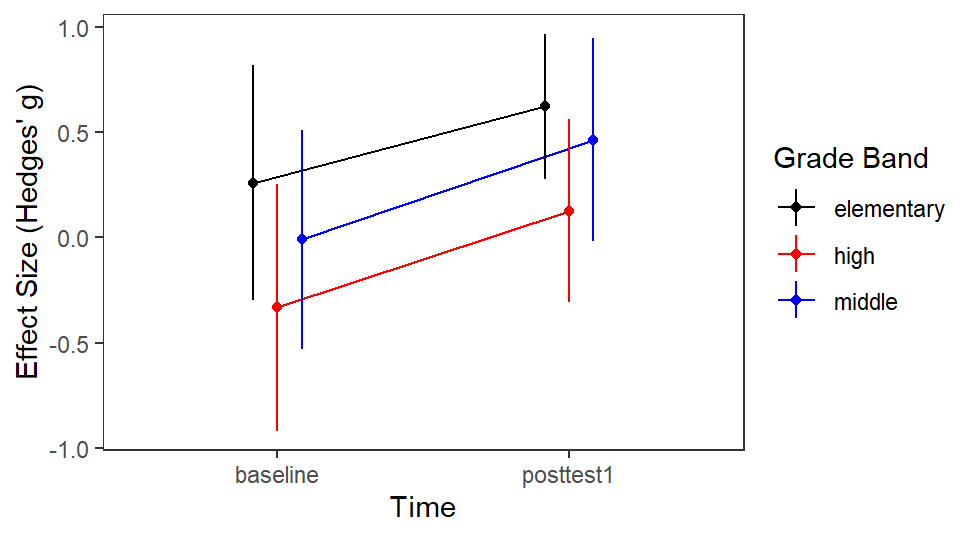

3M results for grade band categories

| grade | time | Mean | SE | Lower | Upper | t | p-value | Sig. | K | M |
| --- | --- | --- | --- | --- | --- | --- | --- | --- | --- | --- |
| elementary | baseline | 0.259 | 0.256 | -0.299 | 0.817 | 1.011 | 0.332 |  | 7 | 13 |
| high | baseline | -0.332 | 0.268 | -0.917 | 0.253 | -1.237 | 0.240 |  | 2 | 12 |
| middle | baseline | -0.009 | 0.238 | -0.528 | 0.509 | -0.039 | 0.969 |  | 4 | 20 |
| elementary | posttest1 | 0.622 | 0.158 | 0.278 | 0.966 | 3.944 | 0.002 | ** | 15 | 54 |
| high | posttest1 | 0.127 | 0.199 | -0.308 | 0.561 | 0.636 | 0.537 |  | 4 | 24 |
| middle | posttest1 | 0.464 | 0.221 | -0.017 | 0.945 | 2.100 | 0.058 | . | 4 | 28 |

R2 test of heterogeneity for grade band

| Model | Total Heterogeneity | Between-study Heterogeneity | Within-study Heterogeneity | p-value | R2 |
| --- | --- | --- | --- | --- | --- |
| No (M)UTOS | 0.686 | 0.000 | 0.686 |  |  |
| Grade Band | 0.655 | 0.000 | 0.655 | 0.107 | 4.435% |

**Note:** <sup>a</sup> Heterogeneity is in SD unit. <sup>b</sup> The *p-value* indicates the statistical significance of the MUTOS moderators in the Grade Band model *collectively*.

### 6.1.7 Tech Level

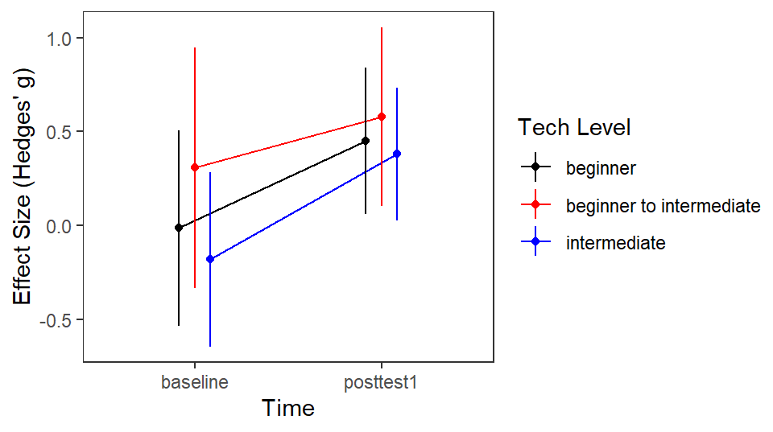

3M results for tech level categories

| tech_level | time | Mean | SE | Lower | Upper | t | p-value | Sig. | K | M |
| --- | --- | --- | --- | --- | --- | --- | --- | --- | --- | --- |
| beginner | baseline | -0.012 | 0.239 | -0.532 | 0.508 | -0.051 | 0.960 |  | 5 | 19 |
| beginner to intermediate | baseline | 0.308 | 0.293 | -0.331 | 0.947 | 1.051 | 0.314 |  | 4 | 10 |
| intermediate | baseline | -0.180 | 0.213 | -0.643 | 0.283 | -0.846 | 0.414 |  | 4 | 16 |
| beginner | posttest1 | 0.451 | 0.179 | 0.062 | 0.840 | 2.527 | 0.027 | * | 9 | 50 |
| beginner to intermediate | posttest1 | 0.578 | 0.218 | 0.102 | 1.054 | 2.646 | 0.021 | * | 6 | 21 |
| intermediate | posttest1 | 0.381 | 0.161 | 0.029 | 0.732 | 2.357 | 0.036 | * | 8 | 35 |

R2 test of heterogeneity for tech level

| Model | Total Heterogeneity | Between-study Heterogeneity | Within-study Heterogeneity | p-value | R2 |
| --- | --- | --- | --- | --- | --- |
| No (M)UTOS | 0.686 | 0.000 | 0.686 |  |  |
| Tech Level | 0.658 | 0.000 | 0.658 | 0.183 | 4.120% |

**Note:** <sup>a</sup> Heterogeneity is in SD unit. <sup>b</sup> The *p-value* indicates the statistical significance of the MUTOS moderators in the Tech Level model *collectively*.

### 6.1.8 Continent

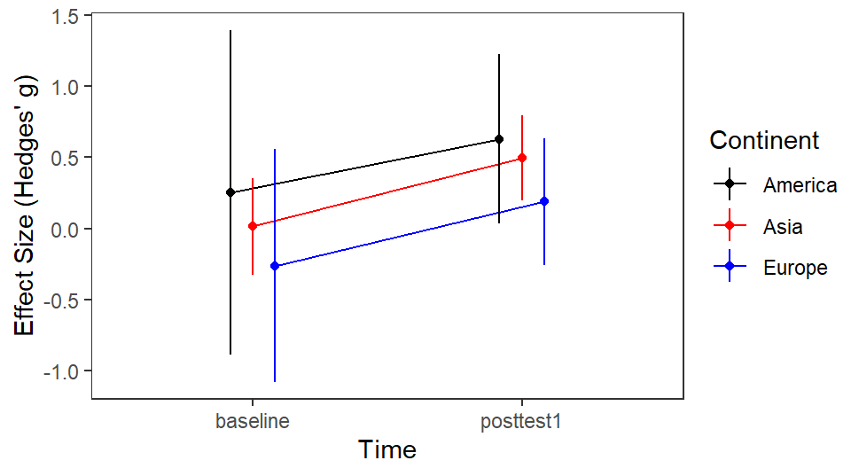

3M results for continent categories

| continent | time | Mean | SE | Lower | Upper | t | p-value | Sig. | K | M |
| --- | --- | --- | --- | --- | --- | --- | --- | --- | --- | --- |
| America | baseline | 0.252 | 0.523 | -0.888 | 1.393 | 0.482 | 0.638 |  | 2 | 2 |
| Asia | baseline | 0.014 | 0.155 | -0.324 | 0.352 | 0.090 | 0.930 |  | 9 | 38 |
| Europe | baseline | -0.260 | 0.375 | -1.076 | 0.556 | -0.695 | 0.500 |  | 2 | 5 |
| America | posttest1 | 0.630 | 0.272 | 0.037 | 1.222 | 2.316 | 0.039 | * | 5 | 11 |
| Asia | posttest1 | 0.497 | 0.137 | 0.198 | 0.796 | 3.623 | 0.003 | ** | 12 | 69 |
| Europe | posttest1 | 0.188 | 0.204 | -0.257 | 0.633 | 0.922 | 0.375 |  | 6 | 26 |

R2 test of heterogeneity for continent

| Model | Total Heterogeneity | Between-study Heterogeneity | Within-study Heterogeneity | p-value | R2 |
| --- | --- | --- | --- | --- | --- |
| No (M)UTOS | 0.686 | 0.000 | 0.686 |  |  |
| Continent | 0.650 | 0.000 | 0.650 | 0.145 | 5.174% |

**Note:** <sup>a</sup> Heterogeneity is in SD unit. <sup>b</sup> The *p-value* indicates the statistical significance of the MUTOS moderators in the Continent model *collectively*.

### 6.1.9 Group Size

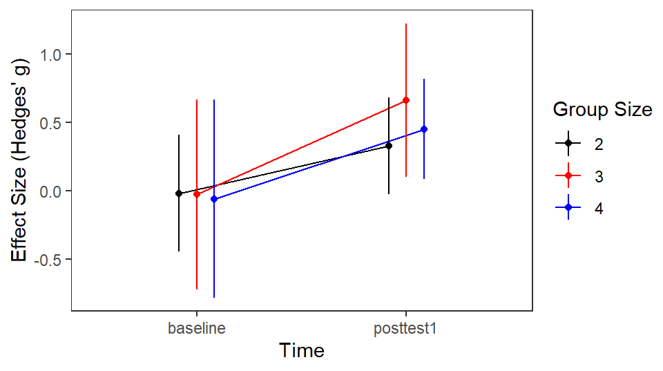

3M results for group size categories

| MAX_grp_size | time | Mean | SE | Lower | Upper | t | p-value | Sig. | K | M |
| --- | --- | --- | --- | --- | --- | --- | --- | --- | --- | --- |
| 2 | baseline | -0.019 | 0.191 | -0.446 | 0.408 | -0.099 | 0.923 |  | 8 | 28 |
| 3 | baseline | -0.027 | 0.312 | -0.723 | 0.668 | -0.087 | 0.933 |  | 2 | 9 |
| 4 | baseline | -0.058 | 0.324 | -0.781 | 0.664 | -0.180 | 0.861 |  | 2 | 7 |
| 21 | baseline | 0.085 | 0.719 | -1.516 | 1.686 | 0.118 | 0.909 |  | 1 | 1 |
| 2 | posttest1 | 0.328 | 0.159 | -0.027 | 0.683 | 2.058 | 0.067 | . | 12 | 46 |
| 3 | posttest1 | 0.662 | 0.252 | 0.102 | 1.223 | 2.633 | 0.025 | * | 4 | 14 |
| 4 | posttest1 | 0.452 | 0.165 | 0.084 | 0.819 | 2.741 | 0.021 | * | 6 | 45 |
| 21 | posttest1 | 1.337 | 0.726 | -0.281 | 2.955 | 1.842 | 0.095 | . | 1 | 1 |

R2 test of heterogeneity for group size

| Model | Total Heterogeneity | Between-study Heterogeneity | Within-study Heterogeneity | p-value | R2 |
| --- | --- | --- | --- | --- | --- |
| No (M)UTOS | 0.686 | 0.000 | 0.686 |  |  |
| Group Size | 0.657 | 0.000 | 0.657 | 0.247 | 4.261% |

**Note:** <sup>a</sup> Heterogeneity is in SD unit. <sup>b</sup> The *p-value* indicates the statistical significance of the MUTOS moderators in the Group Size model *collectively*.

### 6.1.10 Age

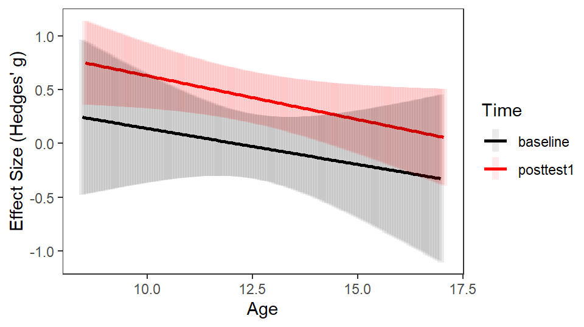

3M results for age categories/trends

| AVERAGE_age | time | AVERAGE_age.trend | SE | Lower | Upper | t | p-value | Sig. |
| --- | --- | --- | --- | --- | --- | --- | --- | --- |
| 12.223 | baseline | -0.067 | 0.075 | -0.229 | 0.095 | -0.888 | 0.389 |  |
| 12.223 | posttest1 | -0.082 | 0.038 | -0.163 | -0.000 | -2.155 | 0.049 | * |

R2 test of heterogeneity for age

| Model | Total Heterogeneity | Between-study Heterogeneity | Within-study Heterogeneity | p-value | R2 |
| --- | --- | --- | --- | --- | --- |
| No (M)UTOS | 0.686 | 0.000 | 0.686 |  |  |
| Age | 0.654 | 0.000 | 0.654 | 0.457 | 4.701% |

**Note:** <sup>a</sup> Heterogeneity is in SD unit. <sup>b</sup> The *p-value* indicates the statistical significance of the MUTOS moderators in the Age model *collectively*.

## 6.2 Learning Gains

```r
rs <- results

invisible(lapply(table_names, \(i){


  cat(paste0("\n\n### ", i, "\n"))


g <- rs[[i]]$ems

# Effects
gains <- if(i=="Time") contrast_rma(g, list("Gain1(post-test 1 - baseline)" =c(2,-1))) else contrast_rma(g, brief = TRUE)


print(kable(dplyr::select(gains$table, -Df),format = "simple", table.attr = "style='width:40%;'",
            caption = paste("Learning gains for", tolower(i))) %>%
  kable_styling(bootstrap_options = "bordered",
                full_width = TRUE, font_size = 9.5))


no <- !i %in% c("Time","Age")

if(no) gain_dif <- contrast_rma(g, gain_dif = TRUE, brief = TRUE, gain_dif_type = "same")

if(no) print(kable(dplyr::select(gain_dif$table, -Df),format = "simple", table.attr = "style='width:40%;'",
            caption = paste("Differences in learning gains for", tolower(i))) %>%
  kable_styling(bootstrap_options = "bordered",
                full_width = TRUE, font_size = 9.5))


# Percentages
if(i!="Age") gain_prob <- prob_rma(gains, gain=TRUE, target_effect=.2)

if(i!="Age") print(kable(gain_prob,format = "simple", table.attr = "style='width:40%;'",
            caption = paste("Minimum learning gain percentage for", tolower(i))) %>%
  kable_styling(bootstrap_options = "bordered",
                full_width = TRUE, font_size = 9.5))

}))
```

### 6.2.1 Time

Learning gains for time

| Contrast | Estimate | SE | Lower | Upper | t | p-value | Sig. |
| --- | --- | --- | --- | --- | --- | --- | --- |
| Gain1(post-test 1 - baseline) | 0.458 | 0.137 | 0.166 | 0.749 | 3.331 | 0.004 | ** |

Minimum learning gain percentage for time

| Term | Target_Effect | Probability | Min | Max |
| --- | --- | --- | --- | --- |
| Gain1(post-test 1 - baseline) | 0.2 or larger | 58.95% | 48.90% | 69.89% |

### 6.2.2 Treatment Type

Learning gains for treatment type

| Contrast | Estimate | SE | Lower | Upper | t | p-value | Sig. |
| --- | --- | --- | --- | --- | --- | --- | --- |
| Gain1(CMC/CSCL) | 0.225 | 0.385 | -0.664 | 1.114 | 0.585 | 0.575 |  |
| Gain1(game-based) | 0.640 | 0.302 | -0.058 | 1.337 | 2.116 | 0.067 | . |
| Gain1(peer tutoring) | 0.627 | 0.390 | -0.272 | 1.526 | 1.608 | 0.147 |  |
| Gain1(programming) | 0.256 | 0.256 | -0.335 | 0.846 | 0.998 | 0.348 |  |
| Gain1(web-based) | 0.762 | 0.323 | 0.017 | 1.507 | 2.358 | 0.046 | * |

Differences in learning gains for treatment type

| Contrast | Estimate | SE | Lower | Upper | t | p-value | Sig. |
| --- | --- | --- | --- | --- | --- | --- | --- |
| Gain1(CMC/CSCL) - Gain1(game-based) | -0.414 | 0.489 | -1.543 | 0.714 | -0.847 | 0.422 |  |
| Gain1(CMC/CSCL) - Gain1(peer tutoring) | -0.401 | 0.548 | -1.665 | 0.863 | -0.732 | 0.485 |  |
| Gain1(CMC/CSCL) - Gain1(programming) | -0.030 | 0.460 | -1.091 | 1.030 | -0.066 | 0.949 |  |
| Gain1(CMC/CSCL) - Gain1(web-based) | -0.536 | 0.506 | -1.703 | 0.631 | -1.060 | 0.320 |  |
| Gain1(game-based) - Gain1(peer tutoring) | 0.013 | 0.493 | -1.125 | 1.150 | 0.026 | 0.980 |  |
| Gain1(game-based) - Gain1(programming) | 0.384 | 0.397 | -0.530 | 1.298 | 0.968 | 0.361 |  |
| Gain1(game-based) - Gain1(web-based) | -0.122 | 0.447 | -1.152 | 0.908 | -0.273 | 0.792 |  |
| Gain1(peer tutoring) - Gain1(programming) | 0.371 | 0.466 | -0.704 | 1.447 | 0.796 | 0.449 |  |
| Gain1(peer tutoring) - Gain1(web-based) | -0.135 | 0.506 | -1.302 | 1.032 | -0.267 | 0.796 |  |
| Gain1(programming) - Gain1(web-based) | -0.506 | 0.414 | -1.461 | 0.449 | -1.222 | 0.256 |  |

Minimum learning gain percentage for treatment type

| Term | Target_Effect | Probability | Min | Max |
| --- | --- | --- | --- | --- |
| Gain1(CMC/CSCL) | 0.2 or larger | 50.86% | 24.55% | 80.46% |
| Gain1(game-based) | 0.2 or larger | 64.83% | 41.85% | 85.71% |
| Gain1(peer tutoring) | 0.2 or larger | 64.41% | 35.34% | 89.34% |
| Gain1(programming) | 0.2 or larger | 51.93% | 33.49% | 72.79% |
| Gain1(web-based) | 0.2 or larger | 68.67% | 44.20% | 89.01% |

### 6.2.3 Outcome Orientation

Learning gains for outcome orientation

|  | Contrast | Estimate | SE | Lower | Upper | t | p-value | Sig. |
| --- | --- | --- | --- | --- | --- | --- | --- | --- |
| 1 | Gain1(cognitive) | 0.450 | 0.172 | 0.068 | 0.833 | 2.626 | 0.025 | * |
| 3 | Gain1(motivational) | 0.457 | 0.310 | -0.233 | 1.147 | 1.476 | 0.171 |  |
| 4 | Gain1(social) | 0.420 | 0.342 | -0.342 | 1.182 | 1.229 | 0.247 |  |

Differences in learning gains for outcome orientation

|  | Contrast | Estimate | SE | Lower | Upper | t | p-value | Sig. |
| --- | --- | --- | --- | --- | --- | --- | --- | --- |
| 2 | Gain1(cognitive) - Gain1(motivational) | -0.007 | 0.354 | -0.795 | 0.781 | -0.019 | 0.985 |  |
| 3 | Gain1(cognitive) - Gain1(social) | 0.030 | 0.375 | -0.805 | 0.866 | 0.080 | 0.937 |  |
| 6 | Gain1(motivational) - Gain1(social) | 0.037 | 0.455 | -0.976 | 1.050 | 0.081 | 0.937 |  |

Minimum learning gain percentage for outcome orientation

| Term | Target_Effect | Probability | Min | Max |
| --- | --- | --- | --- | --- |
| Gain1(cognitive) | 0.2 or larger | 58.59% | 45.80% | 72.45% |
| Gain1(motivational) | 0.2 or larger | 58.83% | 36.46% | 81.38% |
| Gain1(social) | 0.2 or larger | 57.57% | 33.24% | 82.25% |

### 6.2.4 Feedback Availability

Learning gains for feedback availability

| Contrast | Estimate | SE | Lower | Upper | t | p-value | Sig. |
| --- | --- | --- | --- | --- | --- | --- | --- |
| Gain1(with TF) | 0.500 | 0.172 | 0.131 | 0.869 | 2.905 | 0.012 | * |
| Gain1(without TF) | 0.340 | 0.228 | -0.148 | 0.829 | 1.494 | 0.157 |  |

Differences in learning gains for feedback availability

| Contrast | Estimate | SE | Lower | Upper | t | p-value | Sig. |
| --- | --- | --- | --- | --- | --- | --- | --- |
| Gain1(with TF) - Gain1(without TF) | 0.159 | 0.283 | -0.447 | 0.765 | 0.564 | 0.581 |  |

Minimum learning gain percentage for feedback availability

| Term | Target_Effect | Probability | Min | Max |
| --- | --- | --- | --- | --- |
| Gain1(with TF) | 0.2 or larger | 60.36% | 47.78% | 73.76% |
| Gain1(without TF) | 0.2 or larger | 54.88% | 38.94% | 72.50% |

### 6.2.5 Subject

Learning gains for subject

| Contrast | Estimate | SE | Lower | Upper | t | p-value | Sig. |
| --- | --- | --- | --- | --- | --- | --- | --- |
| Gain1(Language & Literacy) | 0.777 | 0.466 | -0.237 | 1.792 | 1.669 | 0.121 |  |
| Gain1(Social Sciences & General Education) | 0.621 | 0.354 | -0.150 | 1.393 | 1.754 | 0.105 |  |
| Gain1(STEM) | 0.389 | 0.159 | 0.042 | 0.735 | 2.444 | 0.031 | * |

Differences in learning gains for subject

| Contrast | Estimate | SE | Lower | Upper | t | p-value | Sig. |
| --- | --- | --- | --- | --- | --- | --- | --- |
| Gain1(Language & Literacy) - Gain1(Social Sciences & General Education) | 0.156 | 0.587 | -1.122 | 1.435 | 0.266 | 0.795 |  |
| Gain1(Language & Literacy) - Gain1(STEM) | 0.389 | 0.493 | -0.684 | 1.462 | 0.790 | 0.445 |  |
| Gain1(Social Sciences & General Education) - Gain1(STEM) | 0.233 | 0.386 | -0.609 | 1.074 | 0.603 | 0.558 |  |

Minimum learning gain percentage for subject

| Term | Target_Effect | Probability | Min | Max |
| --- | --- | --- | --- | --- |
| Gain1(Language & Literacy) | 0.2 or larger | 69.26% | 36.27% | 93.41% |
| Gain1(Social Sciences & General Education) | 0.2 or larger | 64.33% | 38.93% | 87.07% |
| Gain1(STEM) | 0.2 or larger | 56.55% | 44.95% | 69.38% |

### 6.2.6 Grade Band

Learning gains for grade band

| Contrast | Estimate | SE | Lower | Upper | t | p-value | Sig. |
| --- | --- | --- | --- | --- | --- | --- | --- |
| Gain1(elementary) | 0.363 | 0.255 | -0.194 | 0.920 | 1.421 | 0.181 |  |
| Gain1(high) | 0.459 | 0.261 | -0.109 | 1.027 | 1.760 | 0.104 |  |
| Gain1(middle) | 0.473 | 0.214 | 0.006 | 0.940 | 2.208 | 0.047 | * |

Differences in learning gains for grade band

| Contrast | Estimate | SE | Lower | Upper | t | p-value | Sig. |
| --- | --- | --- | --- | --- | --- | --- | --- |
| Gain1(elementary) - Gain1(high) | -0.096 | 0.365 | -0.890 | 0.699 | -0.263 | 0.797 |  |
| Gain1(elementary) - Gain1(middle) | -0.110 | 0.334 | -0.837 | 0.617 | -0.330 | 0.747 |  |
| Gain1(high) - Gain1(middle) | -0.014 | 0.338 | -0.751 | 0.722 | -0.042 | 0.967 |  |

Minimum learning gain percentage for grade band

| Term | Target_Effect | Probability | Min | Max |
| --- | --- | --- | --- | --- |
| Gain1(elementary) | 0.2 or larger | 55.66% | 37.55% | 75.25% |
| Gain1(high) | 0.2 or larger | 58.95% | 40.18% | 78.34% |
| Gain1(middle) | 0.2 or larger | 59.42% | 43.79% | 75.84% |

### 6.2.7 Tech Level

Learning gains for tech level

| Contrast | Estimate | SE | Lower | Upper | t | p-value | Sig. |
| --- | --- | --- | --- | --- | --- | --- | --- |
| Gain1(beginner to intermediate) | 0.270 | 0.296 | -0.375 | 0.915 | 0.913 | 0.379 |  |
| Gain1(beginner) | 0.463 | 0.216 | -0.007 | 0.934 | 2.145 | 0.053 | . |
| Gain1(intermediate) | 0.561 | 0.225 | 0.070 | 1.051 | 2.488 | 0.029 | * |

Differences in learning gains for tech level

| Contrast | Estimate | SE | Lower | Upper | t | p-value | Sig. |
| --- | --- | --- | --- | --- | --- | --- | --- |
| Gain1(beginner to intermediate) - Gain1(beginner) | -0.193 | 0.366 | -0.990 | 0.604 | -0.528 | 0.607 |  |
| Gain1(beginner to intermediate) - Gain1(intermediate) | -0.290 | 0.370 | -1.097 | 0.516 | -0.784 | 0.448 |  |
| Gain1(beginner) - Gain1(intermediate) | -0.097 | 0.310 | -0.772 | 0.577 | -0.315 | 0.758 |  |

Minimum learning gain percentage for tech level

| Term | Target_Effect | Probability | Min | Max |
| --- | --- | --- | --- | --- |
| Gain1(beginner to intermediate) | 0.2 or larger | 52.43% | 32.20% | 75.06% |
| Gain1(beginner) | 0.2 or larger | 59.07% | 43.39% | 75.63% |
| Gain1(intermediate) | 0.2 or larger | 62.35% | 45.84% | 78.96% |

### 6.2.8 Continent

Learning gains for continent

| Contrast | Estimate | SE | Lower | Upper | t | p-value | Sig. |
| --- | --- | --- | --- | --- | --- | --- | --- |
| Gain1(America) | 0.377 | 0.556 | -0.834 | 1.588 | 0.678 | 0.511 |  |
| Gain1(Asia) | 0.483 | 0.154 | 0.148 | 0.819 | 3.138 | 0.009 | ** |
| Gain1(Europe) | 0.448 | 0.371 | -0.360 | 1.256 | 1.209 | 0.250 |  |

Differences in learning gains for continent

| Contrast | Estimate | SE | Lower | Upper | t | p-value | Sig. |
| --- | --- | --- | --- | --- | --- | --- | --- |
| Gain1(America) - Gain1(Asia) | -0.106 | 0.577 | -1.364 | 1.152 | -0.184 | 0.857 |  |
| Gain1(America) - Gain1(Europe) | -0.071 | 0.655 | -1.498 | 1.355 | -0.109 | 0.915 |  |
| Gain1(Asia) - Gain1(Europe) | 0.035 | 0.402 | -0.841 | 0.910 | 0.086 | 0.933 |  |

Minimum learning gain percentage for continent

| Term | Target_Effect | Probability | Min | Max |
| --- | --- | --- | --- | --- |
| Gain1(America) | 0.2 or larger | 56.17% | 20.19% | 90.66% |
| Gain1(Asia) | 0.2 or larger | 59.80% | 48.33% | 72.20% |
| Gain1(Europe) | 0.2 or larger | 58.61% | 32.56% | 84.24% |

### 6.2.9 Group Size

Learning gains for group size

| Contrast | Estimate | SE | Lower | Upper | t | p-value | Sig. |
| --- | --- | --- | --- | --- | --- | --- | --- |
| Gain1(2) | 0.347 | 0.182 | -0.058 | 0.752 | 1.908 | 0.086 | . |
| Gain1(21) | 1.253 | 0.961 | -0.888 | 3.393 | 1.304 | 0.222 |  |
| Gain1(3) | 0.689 | 0.309 | 0.002 | 1.377 | 2.233 | 0.050 | * |
| Gain1(4) | 0.510 | 0.329 | -0.224 | 1.244 | 1.549 | 0.152 |  |

Differences in learning gains for group size

| Contrast | Estimate | SE | Lower | Upper | t | p-value | Sig. |
| --- | --- | --- | --- | --- | --- | --- | --- |
| Gain1(2) - Gain1(21) | -0.906 | 0.978 | -3.085 | 1.273 | -0.926 | 0.376 |  |
| Gain1(2) - Gain1(3) | -0.343 | 0.358 | -1.141 | 0.456 | -0.956 | 0.361 |  |
| Gain1(2) - Gain1(4) | -0.163 | 0.373 | -0.994 | 0.667 | -0.438 | 0.671 |  |
| Gain1(21) - Gain1(3) | 0.563 | 1.009 | -1.685 | 2.812 | 0.558 | 0.589 |  |
| Gain1(21) - Gain1(4) | 0.743 | 1.016 | -1.520 | 3.006 | 0.731 | 0.481 |  |
| Gain1(3) - Gain1(4) | 0.179 | 0.452 | -0.827 | 1.186 | 0.397 | 0.700 |  |

Minimum learning gain percentage for group size

| Term | Target_Effect | Probability | Min | Max |
| --- | --- | --- | --- | --- |
| Gain1(2) | 0.2 or larger | 55.10% | 41.79% | 69.94% |
| Gain1(21) | 0.2 or larger | 82.09% | 19.11% | 99.87% |
| Gain1(3) | 0.2 or larger | 66.52% | 43.68% | 86.74% |
| Gain1(4) | 0.2 or larger | 60.66% | 36.67% | 83.85% |

### 6.2.10 Age

Learning gains for age

| Contrast | Estimate | SE | Lower | Upper | t | p-value | Sig. |
| --- | --- | --- | --- | --- | --- | --- | --- |
| Gain1(12.223) | -0.014 | 0.078 | -0.182 | 0.153 | -0.186 | 0.855 |  |

# 7 Inclusion Studies

The following provides the studies (*k* = 23) that were included in the meta-analysis.

| Reference |
| --- |
| 1- Burns, B., & Coon, H. (1990). Logo programming and peer interactions: An analysis of process-and product-oriented collaborations. Journal of Educational Computing Research, 6(4), 393-410. |
| 2- Chang, S. C., & Hwang, G. J. (2017). Development of an effective educational computer game based on a mission synchronization-based peer-assistance approach. Interactive Learning Environments, 25(5… |
| 3- Cho, Y. H., & Lim, K. Y. (2017). Effectiveness of collaborative learning with 3 D virtual worlds. British Journal of Educational Technology, 48(1), 202-211. |
| 4- Cohen, A., & Scardamalia, M. (1998). Discourse about ideas: Monitoring and regulation in face-to-face and computer-mediated environments. Interactive Learning Environments, 6(1-2), 93-113. |
| 5- Gijlers, H., & de Jong, T. (2009). Sharing and confronting propositions in collaborative inquiry learning. Cognition and Instruction, 27(3), 239-268. |
| 6- Gu, X., Chen, S., Zhu, W., & Lin, L. (2015). An intervention framework designed to develop the collaborative problem-solving skills of primary school students. Educational Technology Research and D… |
| 7- Hsu, T. C., Chang, C., & Liang, Y. S. (2023). Sequential behavior analysis of interdisciplinary activities in computational thinking and efl learning with game-based learning. IEEE Transactions on … |
| 8- Janssen, J., Erkens, G., & Kanselaar, G. (2007). Visualization of agreement and discussion processes during computer-supported collaborative learning. Computers in human behavior, 23(3), 1105-1125. |
| 9- Kapa, E. (1999). Problem solving, planning ability and sharing processes with LOGO. Journal of Computer Assisted Learning, 15(1), 73-84. |
| 10- Kuo, F. R., Hwang, G. J., Chen, S. C., & Chen, S. Y. (2012). A cognitive apprenticeship approach to facilitating web-based collaborative problem solving. Journal of Educational Technology & Societ… |
| 11- Lin, K. Y., Yu, K. C., Hsiao, H. S., Chang, Y. S., & Chien, Y. H. (2020). Effects of web-based versus classroom-based STEM learning environments on the development of collaborative problem-solving… |
| 12- Looi, C. K., Chen, W., & Ng, F. K. (2010). Collaborative activities enabled by GroupScribbles (GS): An exploratory study of learning effectiveness. Computers & Education, 54(1), 14-26. |
| 13- Mevarech, Z. R., & Kramarski, B. (1992). How and how much can cooperative logo environments enhance creativity and social relationships?. Learning and Instruction, 2(3), 259-274. |
| 14- Nastasi, B. K., & Clements, D. H. (1992). Social-cognitive behaviors and higher-order thinking in educational computer environments. Learning and instruction, 2(3), 215-238. |
| 15- Pragnell, M. V., Roselli, T., & Rossano, V. (2006). Can a hypermedia cooperative e-learning environment stimulate constructive collaboration?. Journal of Educational Technology & Society, 9(2), 11… |
| 16- Rojas, M., Nussbaum, M., Guerrero, O., Chiuminatto, P., Greiff, S., Del Rio, R., & Alvares, D. (2022). Integrating a collaboration script and group awareness to support group regulation and emotio… |
| 17- Sins, P. H., Savelsbergh, E. R., van Joolingen, W. R., & van Hout-Wolters, B. H. (2011). Effects of face-to-face versus chat communication on performance in a collaborative inquiry modeling task. … |
| 18- Szewkis, E., Nussbaum, M., Rosen, T., Abalos, J., Denardin, F., Caballero, D., ... & Alcoholado, C. (2011). Collaboration within large groups in the classroom. International Journal of Computer-Su… |
| 19- Tsuei, M. (2011). Development of a peer‐assisted learning strategy in computer‐supported collaborative learning environments for elementary school students. British Journal of Educational Technolo… |
| 20- Tsuei, M. (2012). Using synchronous peer tutoring system to promote elementary students’ learning in mathematics. Computers & Education, 58(4), 1171-1182. |
| 21- Tsuei, M. (2017). Learning behaviours of low-achieving children’s mathematics learning in using of helping tools in a synchronous peer-tutoring system. Interactive Learning Environments, 25 (2), 1… |
| 22- Van der Meij, H., Veldkamp, S., & Leemkuil, H. (2020). Effects of scripting on dialogues, motivation and learning outcomes in serious games. British journal of educational technology, 51(2), 459-4… |
| 23- Van der Meijden, H., & Veenman, S. (2005). Face-to-face versus computer-mediated communication in a primary school setting. Computers in Human behavior, 21(5), 831-859. |